# Unsupervised machine learning

Pablo Barbera

May 2, 2017

## Topic Modeling

While supervised learning is used when we know the categories we want to produce, unsupervised learning (including topic modeling) is used when we do not know the categories. In topic modeling, documents are not assumed to belong to one topic or category, but simultaneously belong to several topics. The topic distributions also vary over documents.

The workhorse function for the topic model is `LDA`, which stands for Latent Dirichlet Allocation, the technical name for this particular kind of model.

We will now use a dataset that contains the lead paragraph of around 5,000 articles about the economy published in the New York Times between 1980 and 2014. As before, we will preprocess the text using the standard set of techniques.

```r
# install.packages("topicmodels")
library(topicmodels)
# reading data and preparing corpus object
nyt <- read.csv("data/nytimes.csv", stringsAsFactors = FALSE)
library(quanteda)
nytcorpus <- corpus(nyt$lead_paragraph)
nytdfm <- dfm(nytcorpus, remove=stopwords("english"), verbose=TRUE,
               removePunct=TRUE, removeNumbers=TRUE)
cdfm <- dfm_trim(nytdfm, min_docfreq = 2)

# we now export to a format that we can run the topic model with
dtm <- convert(nytdfm, to="topicmodels")

# estimate LDA with K topics
K <- 50
lda <- LDA(dtm, k = K, method = "Gibbs",
                control = list(verbose=25L, seed = 123, burnin = 100, iter = 500))
```

```
## K = 50; V = 21298; M = 5000
## Sampling 600 iterations!
## Iteration 25 ...
## Iteration 50 ...
## Iteration 75 ...
## Iteration 100 ...
## Iteration 125 ...
## Iteration 150 ...
## Iteration 175 ...
## Iteration 200 ...
## Iteration 225 ...
## Iteration 250 ...
## Iteration 275 ...
## Iteration 300 ...
## Iteration 325 ...
## Iteration 350 ...
## Iteration 375 ...
## Iteration 400 ...
## Iteration 425 ...
## Iteration 450 ...
## Iteration 475 ...
## Iteration 500 ...
## Iteration 525 ...
## Iteration 550 ...
## Iteration 575 ...
## Iteration 600 ...
## Gibbs sampling completed!
```

We can use `get_terms` to the top `n` terms from the topic model, and `get_topics` to predict the top `k` topic for each document. This will help us interpret the results of the model.

```r
terms <- get_terms(lda, 15)
terms[,5]
```

```
##  [1] "business"     "companies"    "corporate"    "investment"
##  [5] "american"     "executives"   "industries"   "capital"
##  [9] "profits"      "many"         "pay"          "earnings"
## [13] "large"        "businesses"   "corporations"
```

```r
topics <- get_topics(lda, 1)
head(topics)
```

```
## text1 text2 text3 text4 text5 text6
##    25    23    26    11    41    34
```

Let’s take a closer look at some of these topics. To help us interpret the output, we can look at the words associated with each topic and take a random sample of documents highly associated with each topic.

```r
# Topic 5
paste(terms[,5], collapse=", ")
```

```
## [1] "business, companies, corporate, investment, american, executives, industries, capital, profits, many, pay, earnings, large, businesses, corporations"
```

```r
sample(nyt$lead_paragraph[topics==5], 1)
```

```
## [1] "THE steep recession, which battered the American economy in the final months of the old year, poses the greatest problem for business in the new. And the recession also poses the greatest domestic challenge to President Reagan who, having led the nation into this slump, to his Administration…
```

```r
# Topic 9
paste(terms[,9], collapse=", ")
```

```
## [1] "americans, income, people, poverty, according, years, middle, personal, less, poor, study, living, class, incomes, bureau"
```

```r
sample(nyt$lead_paragraph[topics==9], 1)
```

```
## [1] "To the Editor: William P. O'Hare's arguments on the measurement of poverty (''Poverty's Bottom Line,'' Op-Ed Aug. 19) are reasonable enough, but his recommendation is unnecessarily complex. I suggest that the poverty level be more simply defined as the lowest income decile. Besides simplific…
```

```r
# Topic 14
paste(terms[,14], collapse=", ")
```

```
## [1] "mr, president, bush, obama, clinton, campaign, senator, republican, john, presidential, voters, speech, bush's, political, democratic"
```

```r
sample(nyt$lead_paragraph[topics==14], 1)
```

```
## [1] "President Bush on Tuesday urged Saudi Arabia and other members of OPEC to consider the strain the high cost of oil was having on the American economy, addressing an issue that has begun to color the last year of his presidency and dominate the presidential election campaign. Speaking to a gr…
```

```r
# Topic 16
paste(terms[,16], collapse=", ")
```

```
## [1] "jobs, unemployment, workers, labor, job, work, benefits, number, employment, force, statistics, people, added, lost, jobless"
```

```r
sample(nyt$lead_paragraph[topics==16], 1)
```

```
## [1] "Cambridge, Mass. ON Thursday, President Obama will deliver a major speech on America's employment crisis. But too often, what is lost in the call for job creation is a clear idea of what jobs we want to create."
```

You will that often some topics do not make much sense. They just capture the remaining cluster of words, and often correspond to stopwords. For example:

```r
# Topic 1
paste(terms[,1], collapse=", ")
```

```
## [1] "end, america, often, book, recent, economics, made, seen, ideas, however, like, century, line, hand, wrong"
```

```r
sample(nyt$lead_paragraph[topics==1], 1)
```

```
## [1] "For me, the most frightening news in The Times on Sunday was not about North Korea's stepping up its nuclear program, but an article about how American kids are stepping up their use of digital devices: ''Allison Miller, 14, sends and receives 27,000 texts in a month, her fingers clicking at…
```

```r
# Topic 4
paste(terms[,4], collapse=", ")
```

```
## [1] "just, days, day, took, around, decade, seemed, came, part, began, morning, two, office, come, announced"
```

```r
sample(nyt$lead_paragraph[topics==4], 1)
```

```
## [1] "SHORTLY after the planes slammed into the World Trade Center and the Pentagon last week, a reporter called to ask, ''What effect will the terrorist attacks have on the economy?'' ''That's the least of it,'' I replied. How can one even begin to consider the economic costs before the human tol…
```

In the case of date with timestamps, looking at the evolution of certain topics over time can also help interpret their meaning. Let’s look for example at Topic 41, which appears to be related to the stock market.

```r
# Topic 41
paste(terms[,41], collapse=", ")
```

```
## [1] "market, stock, investors, wall, street, yesterday, stocks, markets, average, points, bond, dow, day, industrial, jones"
```

```r
sample(nyt$lead_paragraph[topics==41], 1)
```

```
## [1] "The stock and bond markets rallied strongly yesterday, halting for now the sharpest decline in years, as some traders were encouraged by new signs that the economy was not growing as rapidly as had been thought. In a surge of buying and bargain hunting, traders bid up stock prices, lifting t…
```

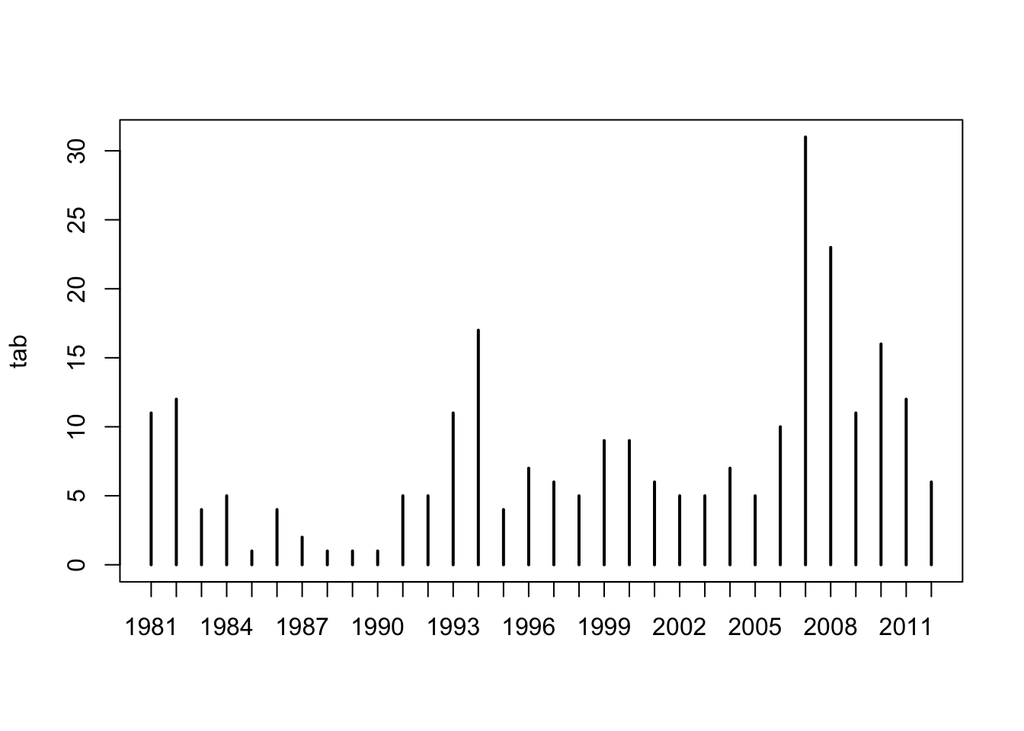

```r
# add predicted topic to dataset
nyt$pred_topic <- topics
nyt$year <- substr(nyt$datetime, 1, 4) # extract year
 # frequency table with articles about stock market, per year
tab <- table(nyt$year[nyt$pred_topic==41])
plot(tab)
```

But we can actually do better than this. LDA is a probabilistic model, which means that for each document, it actually computes a distribution over topics. In other words, each document is considered to be **about a mixture of topics**.

This information is included in the matrix `gamma` in the LDA object (`theta` in the notation we used for the slides). For example, article 1 is 16% about topic 25, 8% about topic 31, 6% about topic 9, and then less than 5% for each of the rest.

```r
round(lda@gamma[1,], 2)
```

```
##  [1] 0.01 0.01 0.01 0.01 0.01 0.02 0.01 0.02 0.06 0.01 0.02 0.02 0.01 0.01
## [15] 0.01 0.02 0.02 0.02 0.02 0.01 0.01 0.01 0.01 0.01 0.16 0.01 0.01 0.01
## [29] 0.02 0.01 0.08 0.01 0.01 0.01 0.02 0.01 0.01 0.02 0.02 0.01 0.01 0.01
## [43] 0.01 0.01 0.01 0.02 0.02 0.02 0.02 0.01
```

So we can actually take the information in the matrix and aggregate it to compute the average probability that an article each year is about a particular topic. Let’s now choose Topic 15, which appears to be related to the financial crisis.

```r
# Topic 15
paste(terms[,15], collapse=", ")
```

```
## [1] "financial, crisis, banks, credit, markets, debt, bank, system, mortgage, enough, loans, biggest, bankers, firms, bailout"
```

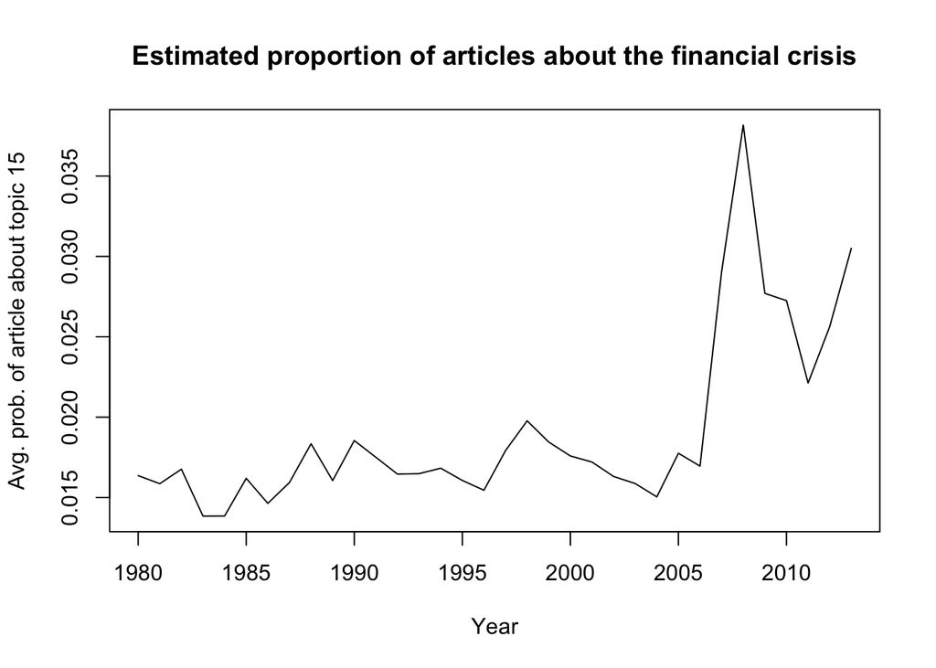

```r
# add probability to df
nyt$prob_topic_15 <- lda@gamma[,15]
# now aggregate at the year level
agg <- aggregate(nyt$prob_topic_15, by=list(year=nyt$year), FUN=mean)
# and plot it
plot(agg$year, agg$x, type="l", xlab="Year", ylab="Avg. prob. of article about topic 15",
     main="Estimated proportion of articles about the financial crisis")
```

## Choosing the number of topics

This is the code to generate the figure in the slides. Many moving parts here…

```r
# install.packages("cvTools")
require(cvTools)
cvLDA <- function(Ntopics,dtm,K=10) {
  folds<-cvFolds(nrow(dtm),K,1)
  perplex <- rep(NA,K)
  llk <- rep(NA,K)
  for(i in unique(folds$which)){
    cat(i, " ")
    which.test <- folds$subsets[folds$which==i]
    which.train <- {1:nrow(dtm)}[-which.test]
    dtm.train <- dtm[which.train,]
    dtm.test <- dtm[which.test,]
    lda.fit <- LDA(dtm.train, k=Ntopics, method="Gibbs",
        control=list(verbose=50L, iter=100))
    perplex[i] <- perplexity(lda.fit,dtm.test)
    llk[i] <- logLik(lda.fit)
  }
  return(list(K=Ntopics,perplexity=perplex,logLik=llk))
}
```

```r
K <- c(20, 30, 40, 50, 60, 70, 80)

results <- list()

i = 1
for (k in K){
    cat("\n\n\n##########\n ", k, "topics", "\n")
    res <- cvLDA(k, dtm)
    results[[i]] <- res
    i = i + 1
}
```

[output not shown]

[output cut: 680 more lines]

```
## K = 80; V = 21298; M = 500
## Sampling 100 iterations!
## Iteration 50 ...
## Iteration 100 ...
## Gibbs sampling completed!
## 10  K = 80; V = 21298; M = 4500
## Sampling 100 iterations!
## Iteration 50 ...
## Iteration 100 ...
## Gibbs sampling completed!
## K = 80; V = 21298; M = 500
## Sampling 100 iterations!
## Iteration 50 ...
## Iteration 100 ...
## Gibbs sampling completed!
```

```r
## plot
df <- data.frame(
    k = rep(K, each=10),
    perp =  unlist(lapply(results, '[[', 'perplexity')),
    loglk = unlist(lapply(results, '[[', 'logLik')),
    stringsAsFactors=F)

min(df$perp)
```

```
## [1] 2424.736
```

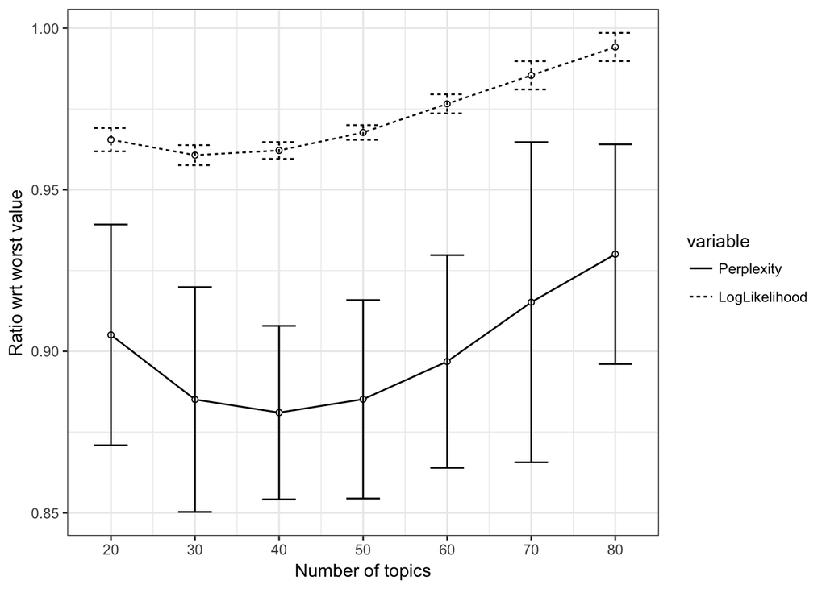

```r
df$ratio_perp <- df$perp / max(df$perp)
df$ratio_lk <- df$loglk / min(df$loglk)

df <- data.frame(cbind(
    aggregate(df$ratio_perp, by=list(df$k), FUN=mean),
    aggregate(df$ratio_perp, by=list(df$k), FUN=sd)$x,
    aggregate(df$ratio_lk, by=list(df$k), FUN=mean)$x,
    aggregate(df$ratio_lk, by=list(df$k), FUN=sd)$x),
    stringsAsFactors=F)
names(df) <- c("k", "ratio_perp", "sd_perp", "ratio_lk", "sd_lk")
library(reshape)
pd <- melt(df[,c("k","ratio_perp", "ratio_lk")], id.vars="k")
pd2 <- melt(df[,c("k","sd_perp", "sd_lk")], id.vars="k")
pd$sd <- pd2$value
levels(pd$variable) <- c("Perplexity", "LogLikelihood")

library(ggplot2)
library(grid)

p <- ggplot(pd, aes(x=k, y=value, linetype=variable))
pq <- p + geom_line() + geom_point(aes(shape=variable),
        fill="white", shape=21, size=1.40) +
    geom_errorbar(aes(ymax=value+sd, ymin=value-sd), width=4) +
    scale_y_continuous("Ratio wrt worst value") +
    scale_x_continuous("Number of topics",
        breaks=K) +
    theme_bw()
pq
```

## Wordfish

To explore an unsupervised approach to ideological scaling, let’s come back to our previous example of tweets by Members of Congress. Can we recover a latent ideological dimension based on the text of their tweets?

```r
cong <- read.csv("data/congress-tweets.csv", stringsAsFactors=F)
# creating the corpus and dfm objects
ccorpus <- corpus(cong$text)
docnames(ccorpus) <- cong$screen_name
cdfm <- dfm(ccorpus, remove=c(stopwords("english"),
              "t.co", "https", "rt", "amp", "http", "t.c", "can"),
            removePunct=TRUE, removeNumbers=TRUE, verbose=TRUE)
```

```
## Creating a dfm from a corpus ...
```

```
##    ... lowercasing
```

```
##    ... tokenizing
```

```
##    ... found 100 documents, 182,596 features
```

```
## ...
```

```
## removed 179 features, from 181 supplied (glob) feature types
```

```
##    ... created a 100 x 182,417 sparse dfm
##    ... complete.
## Elapsed time: 3.81 seconds.
```

```r
# note heavy feature selection!
cdfm <- dfm_trim(cdfm, min_docfreq = 25)
# running wordfish
wf <- textmodel(cdfm, dir=c(10, 8), model="wordfish")
wf
```

```
## Fitted wordfish model:
## Call:
##  textmodel_wordfish(data = x, dir = ..1)
##
## Estimated document positions:
##
##           Documents       theta          SE       lower       upper
## 1       usreprodney -0.34424527 0.066938995 -0.47544570 -0.21304484
## 2       reprichmond -0.73543849 0.024439213 -0.78333935 -0.68753764
## 3       rephanabusa -0.32209192 0.036778896 -0.39417855 -0.25000528
## 4   repstevestivers  0.99632528 0.025052576  0.94722223  1.04542833
## 5    chrisvanhollen -0.93079439 0.019219714 -0.96846503 -0.89312375
## 6   marshablackburn  1.23358119 0.017876322  1.19854360  1.26861878
## 7      repjohnlewis -0.98686852 0.017638600 -1.02144018 -0.95229687
## 8       repstutzman  1.30127291 0.027225813  1.24791031  1.35463550
```

[output cut: 107 more lines]

```r
# let's look at the most discriminant words (note same notation as in slides)
sw <- data.frame(beta=wf@beta, word=wf@features)
sw <- sw[order(sw$beta),]
head(sw, n=20)
```

```
##            beta              word
## 654  -15.957314    #climatechange
## 793  -12.051696     #actonclimate
## 280   -9.239927               #p2
## 735   -6.901741    @waysmeanscmte
## 748   -6.341673   @repjohnconyers
## 1421  -6.117191    @repsandylevin
## 2223  -5.034157     @keithellison
## 1925  -4.882505         pollution
## 1148  -4.580269             #lgbt
## 1382  -4.138735     #womensucceed
## 2899  -4.069306         @lcvoters
## 609   -3.892332        #timeisnow
## 485   -3.700894              #cir
## 1556  -3.577005 #stopthesequester
## 556   -3.560980      #gopshutdown
## 2606  -3.516540    @janschakowsky
## 244   -3.425171          #renewui
## 1937  -3.201671         #equality
## 1319  -3.184053      #demandavote
## 1820  -2.692937             #enda
```

```r
tail(sw, n=20)
```

```
##          beta             word
## 3534 1.489407           comply
## 1810 1.529350      #fullrepeal
## 1340 1.531603  #balancedbudget
## 55   1.597392            #tcot
## 1946 1.615709      #trainwreck
## 120  1.696816           #4jobs
## 239  1.710324             #irs
## 2452 1.738835     house-passed
## 1891 1.739158  #fairnessforall
## 2686 1.754148      bureaucrats
## 448  1.764837   @gopconference
## 805  1.787797         @gopwhip
## 705  1.829968             j.mp
## 1052 1.925021 @waysandmeansgop
## 1182 2.495151 @republicanstudy
## 1541 2.520266           emails
## 1045 2.647682     @reptomprice
## 1502 3.167541             lois
## 383  3.544147     @darrellissa
## 374  6.889297    @gopoversight
```

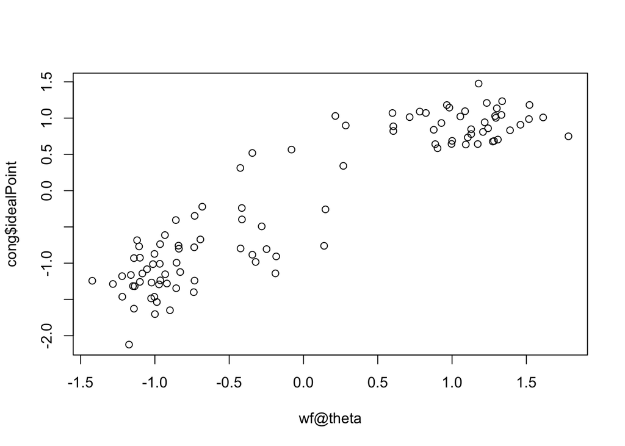

```r
# and now we can compare the estimate positions with the ideal points...
plot(wf@theta, cong$idealPoint)
```

```r
cor(wf@theta, cong$idealPoint)
```

```
## [1] 0.920498
```

```r
cor(wf@theta[cong$party=="R"], cong$idealPoint[cong$party=="R"])
```

```
## [1] 0.4300865
```

```r
cor(wf@theta[cong$party=="D"], cong$idealPoint[cong$party=="D"])
```

```
## [1] 0.5244476
```